# Anxiety Ratings Across Three Raters

Abderrezzaq KADOUCHE

## **Introduction**

Inter-rater reliability is a key aspect of clinical research, particularly when clinical assessments involve subjective evaluations performed by multiple observers. Differences in ratings may reflect variability between raters rather than actual differences between subjects.

Assessing inter-rater reliability is therefore essential to determine the consistency and reproducibility of clinical measurements and to ensure the reliability of collected data.

## **Objective**

The primary objective is to assess the inter-rater reliability of anxiety ratings assigned by three raters to the same 20 subjects.

## **Study Design and Data**

The dataset consists of artificial data representing anxiety assessments for 20 subjects, independently evaluated by three raters.

Each subject received three ratings, one from each rater, using a six-point ordinal scale ranging from 1 (not anxious at all) to 6 (extremely anxious).

The dataset includes 20 subjects and three raters, resulting in 60 individual ratings.

The study follows a crossed measurement design, as all three raters assess the same subjects. This structure allows the evaluation of inter-rater reliability and the comparison of individual versus averaged ratings.

## **Variable Specifications**

- `rater1`: Anxiety rating assigned by the first rater. Values ranging from 1 (Not anxious at all) to 6 (Extremely anxious).
- `rater2`: Anxiety rating assigned by the second rater. Values ranging from 1 (Not anxious at all) to 6 (Extremely anxious).
- `rater3`: Anxiety rating assigned by the third rater. Values ranging from 1 (Not anxious at all) to 6 (Extremely anxious).

## **Descriptive analysis**

```r
# Vérification des modalités
lapply(anxiety, table)
```

```
## $rater1
##
## 1 2 3 4 5 6
## 2 6 5 2 4 1
##
## $rater2
##
## 1 2 3 4 6
## 1 5 8 4 2
##
## $rater3
##
## 1 2 3 4 6
## 7 5 5 2 1
```

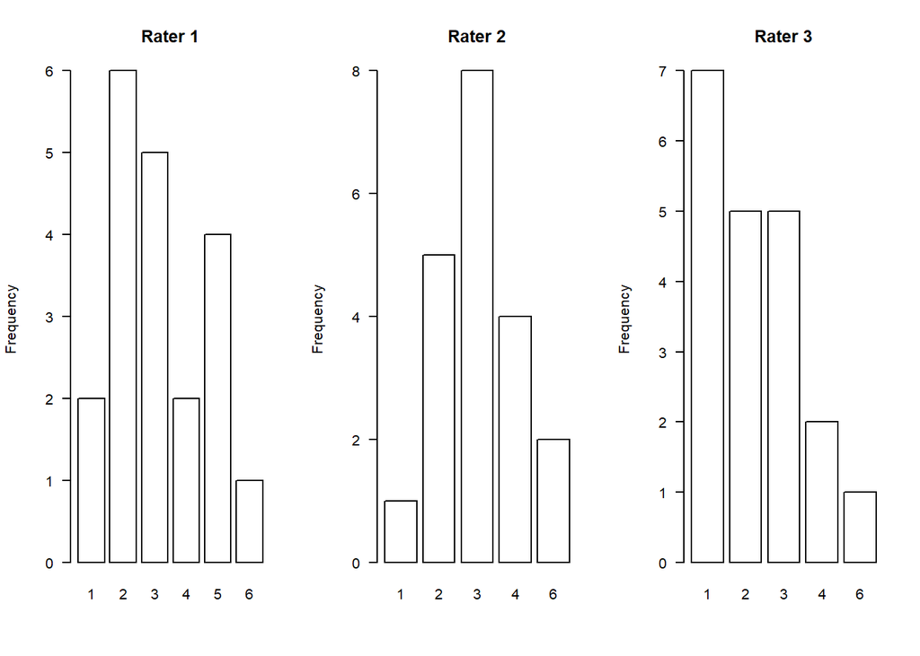

```r
par(mfrow = c(1, 3))

# ── 1. RATER1 ──────────────────────────────────────
barplot(
  table(anxiety$rater1),
  ylab      = "Frequency",
  main      = "Rater 1",
  col       = "white",
  border    = "black",
  las       = 1,
  cex.names = 1.0,
  cex.lab   = 1.0
)

# ── 2. RATER2 ───────────
barplot(
  table(anxiety$rater2),
  ylab      = "Frequency",
  main      = "Rater 2",
  col       = "white",
  border    = "black",
  las       = 1,
  cex.names = 1.0,
  cex.lab   = 1.0
)

# ── 3. Rater 3 ───────────────
barplot(
  table(anxiety$rater3),
  ylab      = "Frequency",
  main      = "Rater 3",
  col       = "white",
  border    = "black",
  las       = 1,
  cex.names = 1.0,
  cex.lab   = 1.0
)
```

## **Missing data**

```r
tab_NA <- data.frame(
  Variables = names(anxiety),
  n_NA = colSums(is.na(anxiety)),
  percent_NA = round(colMeans(is.na(anxiety)) * 100, 2),
  row.names = NULL )

print(tab_NA)
```

```
##   Variables n_NA percent_NA
## 1    rater1    0          0
## 2    rater2    0          0
## 3    rater3    0          0
```

# **Correlation Between Anxiety Ratings Across Raters**

The Spearman correlation matrix shows weak to moderate positive correlations between the three raters. (We used Spearman’s rank correlation coefficient instead of Pearson’s correlation coefficient because the anxiety scores are measured on a 6-point ordinal scale.)

- Rater 1 and Rater 2 (ρ = 0.42): A moderate positive correlation, indicating that higher anxiety scores assigned by one rater tend to be associated with higher scores assigned by the other.
- Rater 1 and Rater 3 (ρ = 0.17): A weak positive correlation, suggesting a limited association between their ratings.
- Rater 2 and Rater 3 (ρ = 0.34): A weak to moderate positive correlation, indicating some consistency in the ranking of subjects.

The correlations suggest limited to moderate consistency in the ranking of subjects across raters.

The strongest association is observed between Rater 1 and Rater 2, whereas the weakest is observed between Rater 1 and Rater 3.

However, Spearman correlation measures the strength of association between ratings, not absolute agreement. Therefore, these results do not establish inter-rater reliability. An Intraclass Correlation Coefficient (ICC) analysis will be performed to further assess agreement among the three raters.

```r
round(cor(anxiety, method = "spearman"),2)
```

```
##        rater1 rater2 rater3
## rater1   1.00   0.42   0.17
## rater2   0.42   1.00   0.34
## rater3   0.17   0.34   1.00
```

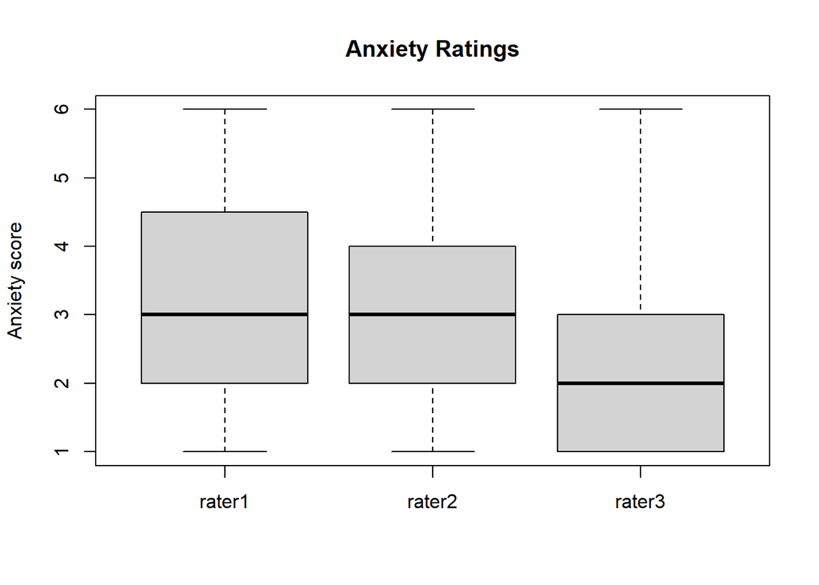

```r
boxplot(
  anxiety,
  main = "Anxiety Ratings",
  ylab = "Anxiety score",
  ylim = c(1, 6)
)
```

## **Statistical Modeling**

The ICC analysis was performed using a two-way model with absolute agreement and a single-measure unit.

# **Results**

## **Intraclass Correlation Coefficient**

The estimated ICC was 0.198, indicating poor inter-rater reliability.

This suggests that the agreement between the three raters is low when considering individual ratings.

```r
# interprétation de l'ICC

#According to Koo and Li (2016):

# ICC < 0.50 = poor reliability;

# 0.50–0.75 = moderate reliability;

# 0.75–0.90 = good reliability;

# ICC > 0.90 = excellent reliability.
```

## **Statistical significance**

The F-test gave the following result: - F(19, 38) = 1.83 - p-value = 0.0562 The p-value is slightly above the conventional significance threshold of 0.05. Therefore, there is insufficient statistical evidence to reject the null hypothesis of zero ICC at the 5% significance level.

## **95% Confidence Interval**

The 95% confidence interval ranged from -0.039 to 0.494.

## **Interpretation**

The results indicate poor inter-rater reliability among the three raters. The low ICC suggests that individual anxiety assessments are not sufficiently consistent in terms of absolute agreement.

However, the confidence interval is wide, reflecting the limited sample size (20 subjects). These findings should therefore be interpreted cautiously.

```r
# 1) ICC

library(irr)

icc(
  anxiety,
  model = "twoway",     # Modèle à deux facteurs : les mêmes évaluateurs notent tous les sujets
  type = "agreement",   # Évalue l'accord absolu entre les évaluateurs
  unit = "single"       # Évalue la fiabilité d'une seule évaluation
)
```

```
##  Single Score Intraclass Correlation
##
##    Model: twoway
##    Type : agreement
##
##    Subjects = 20
##      Raters = 3
##    ICC(A,1) = 0.198
##
##  F-Test, H0: r0 = 0 ; H1: r0 > 0
##    F(19,38) = 1.83 , p = 0.0562
##
##  95%-Confidence Interval for ICC Population Values:
##   -0.039 < ICC < 0.494
```

## **Bland-Altman plots**

These Bland-Altman plots are presented for exploratory purposes only because anxiety scores are ordinal (6-point scale) rather than continuous quantitative measurements.

The intervals between score categories cannot be assumed to be equal, which limits the validity of mean differences and limits of agreement.

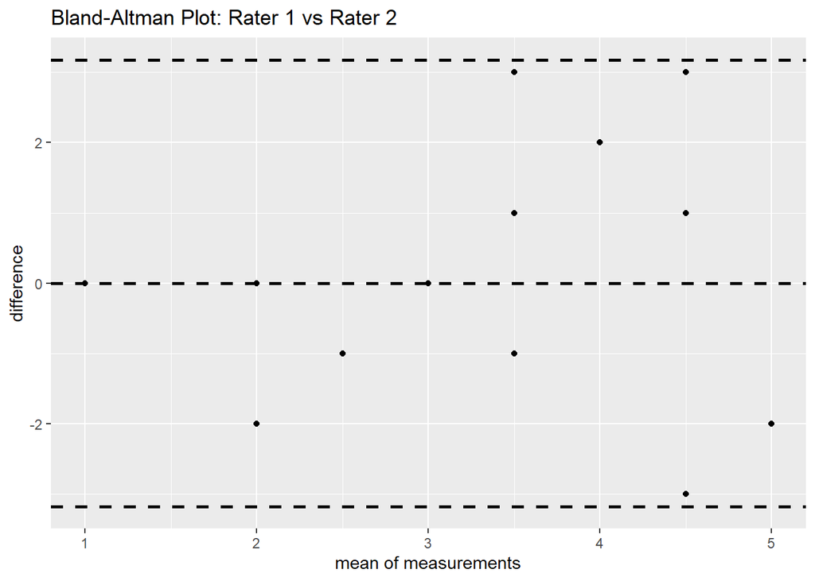

```r
par(mfrow = c(1, 2))

# 2) Graphique Bland et Altman

library(BlandAltmanLeh)
library(ggplot2)

# Bland-Altman : Rater 1 vs Rater 2
bland.altman.plot(
  anxiety$rater1,
  anxiety$rater2,
  graph.sys = "ggplot2") +
  ggtitle("Bland-Altman Plot: Rater 1 vs Rater 2")
```

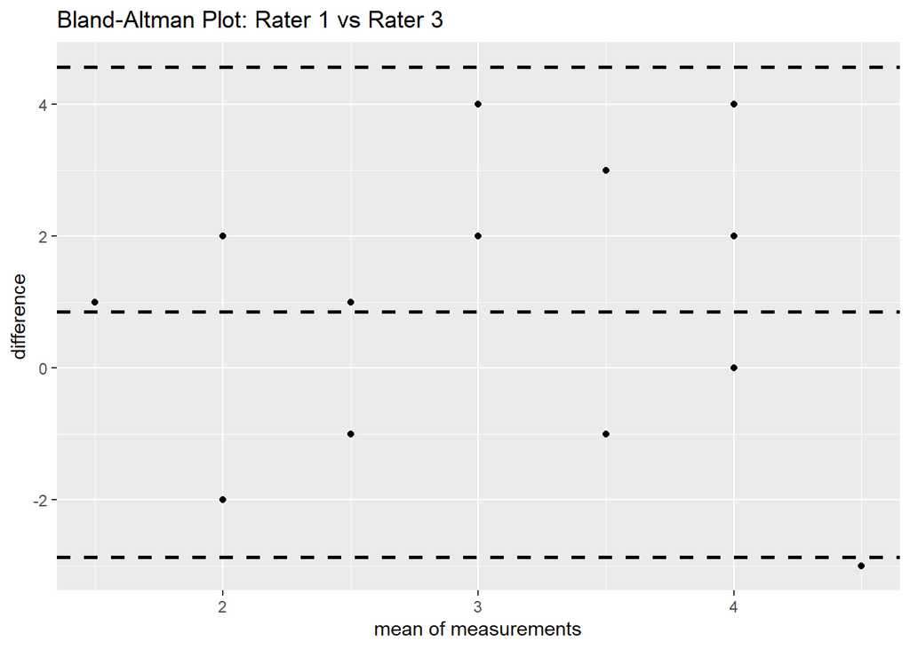

```r
# Bland-Altman : Rater 1 vs Rater 3
bland.altman.plot(
  anxiety$rater1,
  anxiety$rater3,
  graph.sys = "ggplot2") +
  ggtitle("Bland-Altman Plot: Rater 1 vs Rater 3")
```

# **Conclusion**

The ICC analysis revealed poor inter-rater reliability among the three raters (ICC = 0.198; 95% CI: -0.039 to 0.494).

The associated F-test was not statistically significant (p = 0.0562).

These findings suggest limited agreement between raters when considering individual anxiety assessments. However, the wide confidence interval indicates substantial uncertainty, which may partly be explained by the small sample size.